# Children’s Council Annual Report

## Overview

There are approximately 114,000 children under 18 living in Monterey County. That is 26.4% of the population (ACS 2017 DP05). Of them, 21.6% live in poverty (ACS 2017 DP03).

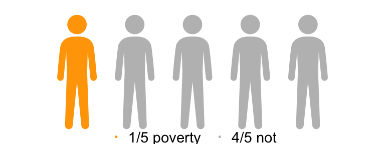

## Demographics

Monterey County students represent a diversity of backgrounds.

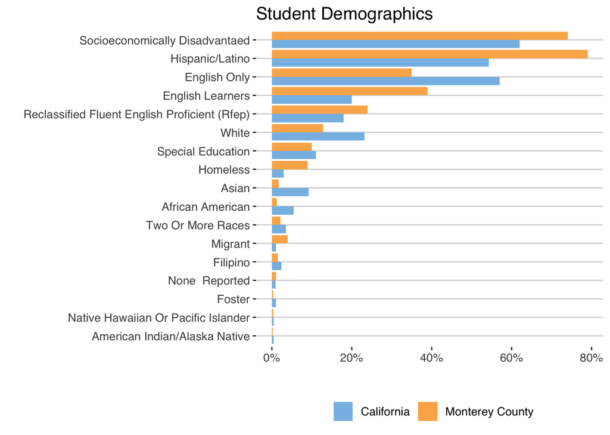

[figure not shown]

There are approximately 8,882.00 migrant students EiP in Monterey County. This is 11.39% of enrolled students compared with 1.41% for California. For Monterey County, approximately 31.45% are Non-Attending, and Non-Attending students are primarily aged 17 and older.

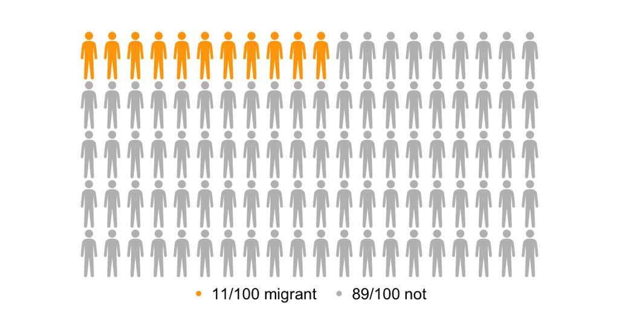

## CAASPP Scores

The California Assessment of Student Performance and Progress (CAASPP) System consists of the following assessments:

- Smarter Balanced English language arts/literacy and mathematics
- California Alternate Assessments for English language arts, mathematics, and science
- California Science Tests
- California Spanish Assessment

We see the successes and disparities that exist in our county.

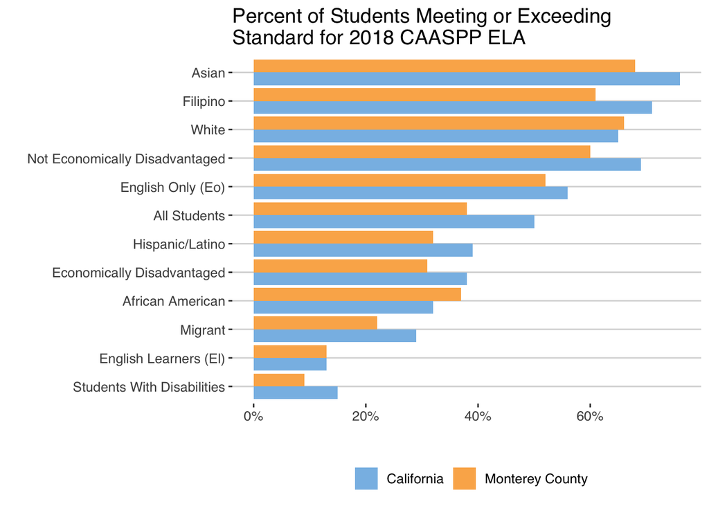

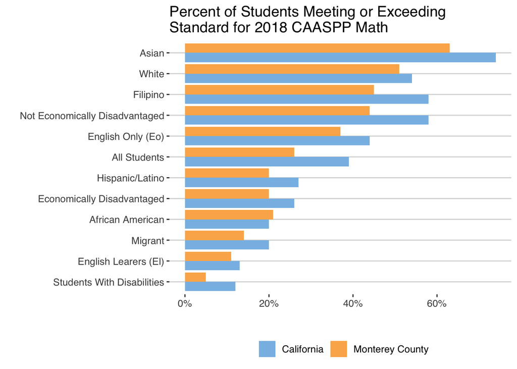

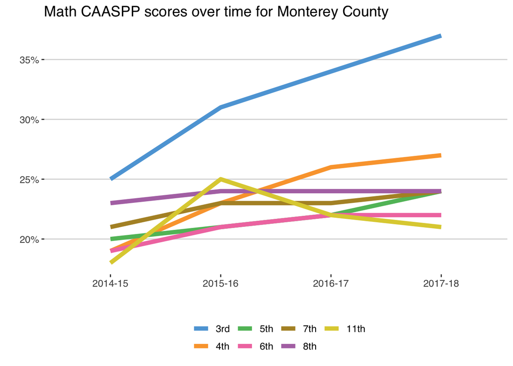

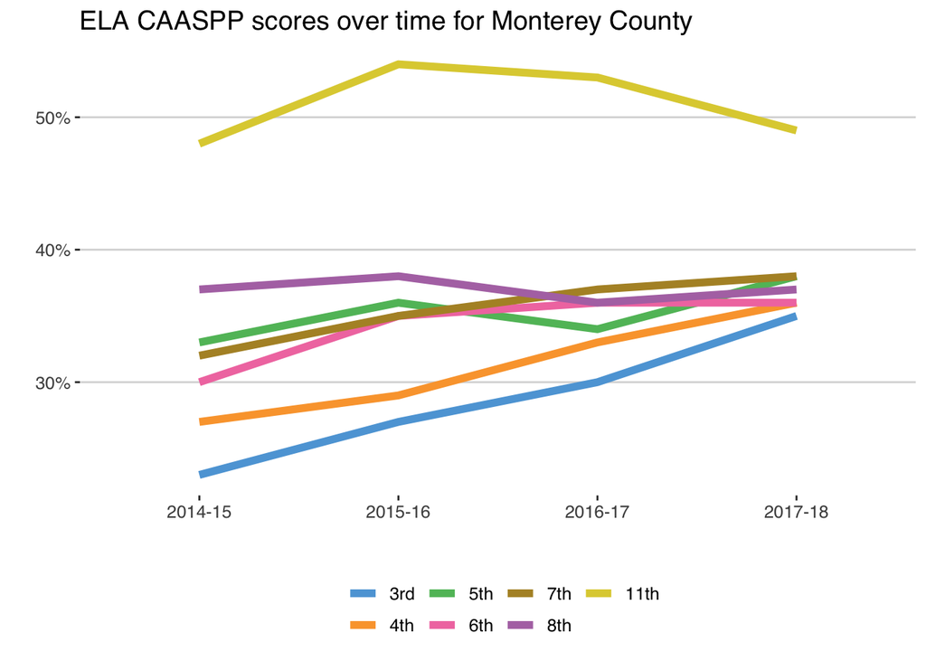

[figure not shown]

## Graduation

Over the past decade, the percentage of students graduating as steadily risen and is a higher rate than California as a whole.

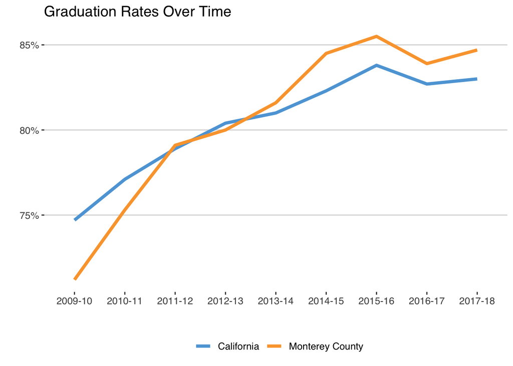

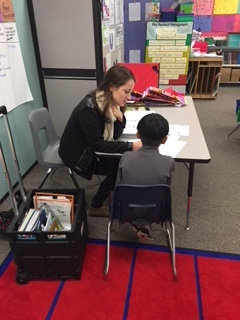

Looking at groups of students we see variance in the rates of graduation.

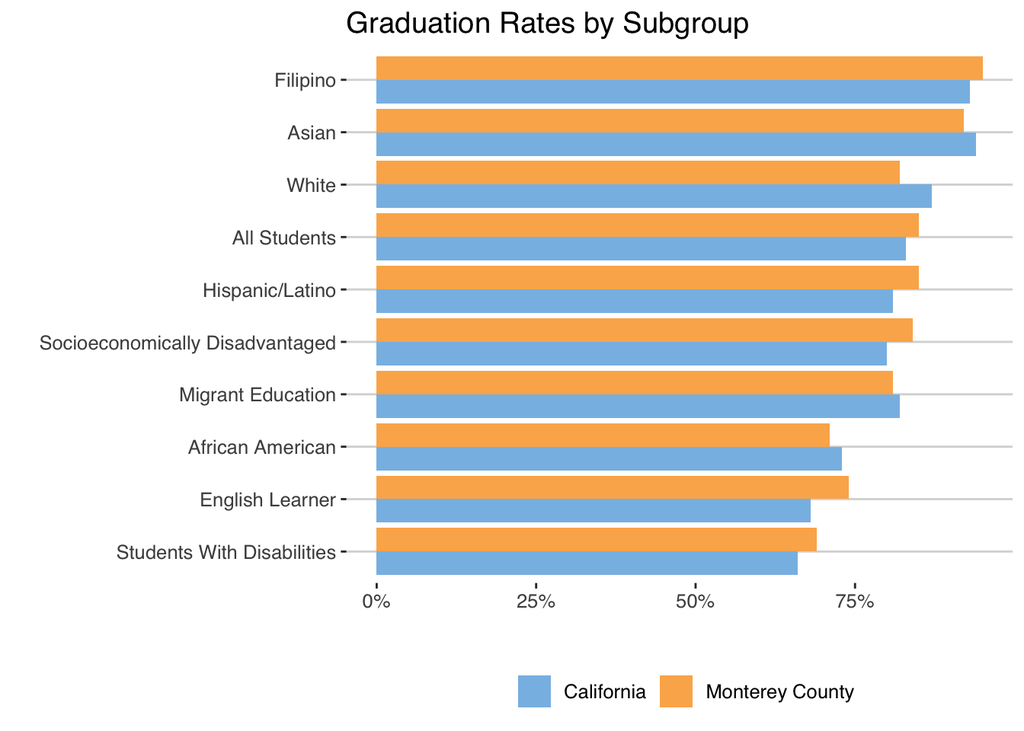

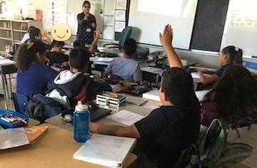

## School Context

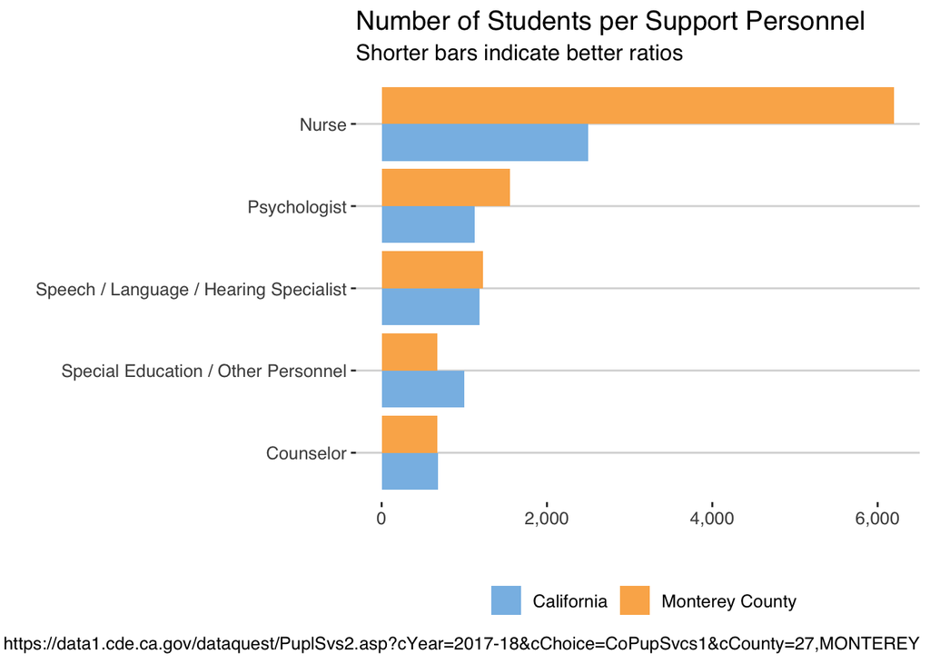

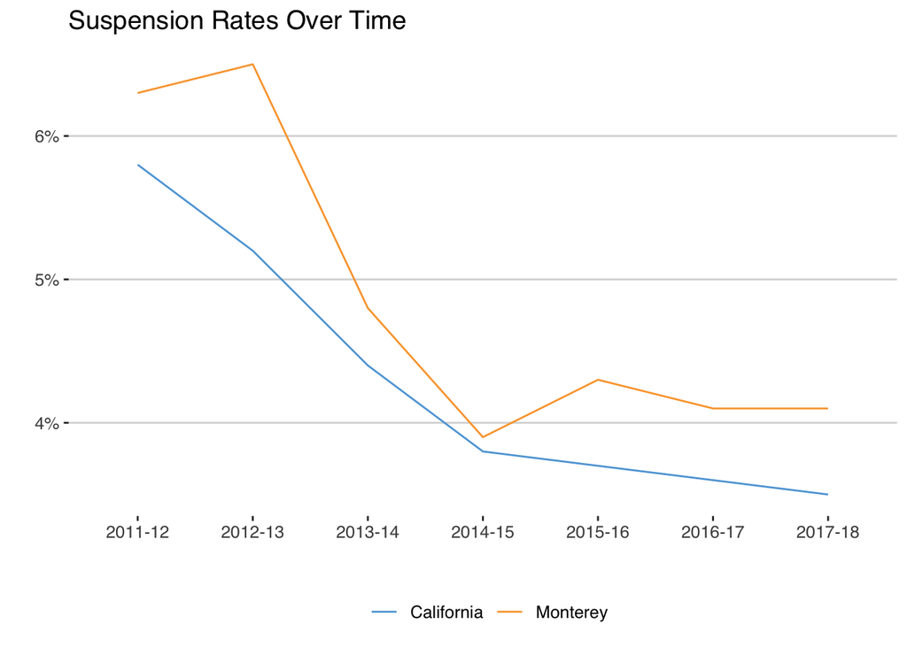

Suspensions have decreased in the past decade, and they remain higher than the rate for California as a whole.